# FPL analysis 2025/2026

I follow this tutorial for reading the data as a JSON and then parsing it: https://medium.com/analytics-vidhya/getting-started-with-fantasy-premier-league-data-56d3b9be8c32

Over the following snippets, we read in the fpl data, we merge players with team data so we can record their position and team. We then tidy the data for analysis.

```python
#!pip install numpy
#!pip install requests
#!pip install pandas
#!pip install scikit-learn
#!pip install scipy
#!pip install matplotlib
```

```python
import requests, json
from pprint import pprint
```

```python
# base url for all FPL API endpoints
base_url = 'https://fantasy.premierleague.com/api/'

# get data from bootstrap-static endpoint
r = requests.get(base_url+'bootstrap-static/').json()

# show the top level fields
#pprint(r, indent=2, depth=1, compact=True)
```

```python
import pandas as pd
pd.set_option('display.max_columns', None)
# create players dataframe
players = pd.json_normalize(r['elements'])

# show some information about first five players
players[['id', 'web_name', 'team', 'element_type']].head()
```

|  | id | web_name | team | element_type |
| --- | --- | --- | --- | --- |
| 0 | 1 | Raya | 1 | 1 |
| 1 | 2 | Arrizabalaga | 1 | 1 |
| 2 | 3 | Hein | 1 | 1 |
| 3 | 4 | Setford | 1 | 1 |
| 4 | 5 | Gabriel | 1 | 2 |

```python
#players.to_csv('players.csv', index=False)
```

```python
players.head()
players.columns
```

```
Index(['can_transact', 'can_select', 'chance_of_playing_next_round',
       'chance_of_playing_this_round', 'code', 'cost_change_event',
       'cost_change_event_fall', 'cost_change_start', 'cost_change_start_fall',
       'dreamteam_count',
       ...
       'now_cost_rank_type', 'form_rank', 'form_rank_type',
       'points_per_game_rank', 'points_per_game_rank_type', 'selected_rank',
       'selected_rank_type', 'starts_per_90', 'clean_sheets_per_90',
       'defensive_contribution_per_90'],
      dtype='object', length=101)
```

```python
teams = pd.json_normalize(r['teams'])

teams.head()
```

|  | code | draw | form | id | loss | name | played | points | position | short_name | strength | team_division | unavailable | win | strength_overall_home | strength_overall_away | strength_attack_home | strength_attack_away | strength_defence_home | strength_defence_away | pulse_id |
| --- | --- | --- | --- | --- | --- | --- | --- | --- | --- | --- | --- | --- | --- | --- | --- | --- | --- | --- | --- | --- | --- |
| 0 | 3 | 0 | None | 1 | 0 | Arsenal | 0 | 0 | 0 | ARS | 4 | None | False | 0 | 1320 | 1325 | 1350 | 1350 | 1290 | 1300 | 1 |
| 1 | 7 | 0 | None | 2 | 0 | Aston Villa | 0 | 0 | 0 | AVL | 3 | None | False | 0 | 1125 | 1250 | 1110 | 1200 | 1140 | 1300 | 2 |
| 2 | 90 | 0 | None | 3 | 0 | Burnley | 0 | 0 | 0 | BUR | 2 | None | False | 0 | 1050 | 1050 | 1050 | 1050 | 1050 | 1050 | 43 |
| 3 | 91 | 0 | None | 4 | 0 | Bournemouth | 0 | 0 | 0 | BOU | 3 | None | False | 0 | 1150 | 1180 | 1100 | 1160 | 1200 | 1200 | 127 |
| 4 | 94 | 0 | None | 5 | 0 | Brentford | 0 | 0 | 0 | BRE | 3 | None | False | 0 | 1120 | 1185 | 1080 | 1080 | 1160 | 1290 | 130 |

```python
positions = pd.json_normalize(r['element_types'])

positions.head()
```

|  | id | plural_name | plural_name_short | singular_name | singular_name_short | squad_select | squad_min_select | squad_max_select | squad_min_play | squad_max_play | ui_shirt_specific | sub_positions_locked | element_count |
| --- | --- | --- | --- | --- | --- | --- | --- | --- | --- | --- | --- | --- | --- |
| 0 | 1 | Goalkeepers | GKP | Goalkeeper | GKP | 2 | None | None | 1 | 1 | True | [12] | 79 |
| 1 | 2 | Defenders | DEF | Defender | DEF | 5 | None | None | 3 | 5 | False | [] | 223 |
| 2 | 3 | Midfielders | MID | Midfielder | MID | 5 | None | None | 2 | 5 | False | [] | 302 |
| 3 | 4 | Forwards | FWD | Forward | FWD | 3 | None | None | 1 | 3 | False | [] | 71 |

```python
df = pd.merge(
    left=players,
    right=teams,
    left_on='team',
    right_on='id'
)

# show joined result
df[['first_name', 'second_name', 'name']].head()
# join player positions
df = df.merge(
    positions,
    left_on='element_type',
    right_on='id'
)

# rename columns
df = df.rename(
    columns={'name':'team_name', 'singular_name':'position_name'}
)

# show result
df[
    ['first_name', 'second_name', 'team_name', 'position_name']
].head()

df[
    ['first_name', 'second_name', 'team_name', 'position_name', 'now_cost', 'points_per_game', 'removed',
       'second_name', 'selected_by_percent', 'special', 'squad_number',
       'status', 'team', 'team_code', 'total_points', 'transfers_in',
       'transfers_in_event', 'transfers_out', 'transfers_out_event',
       'value_form', 'value_season', 'web_name', 'region', 'team_join_date',
       'birth_date', 'has_temporary_code', 'opta_code', 'minutes',
       'goals_scored', 'assists', 'clean_sheets', 'goals_conceded',
       'own_goals', 'penalties_saved', 'penalties_missed', 'yellow_cards',
       'red_cards', 'saves', 'bonus', 'bps', 'influence', 'creativity',
       'threat', 'ict_index', 'defensive_contribution', 'starts',
       'expected_goals', 'expected_assists', 'expected_goal_involvements',
       'expected_goals_conceded', 'influence_rank', 'influence_rank_type',
       'creativity_rank', 'creativity_rank_type', 'threat_rank',
       'threat_rank_type', 'ict_index_rank', 'ict_index_rank_type',
       'corners_and_indirect_freekicks_order',
       'corners_and_indirect_freekicks_text', 'direct_freekicks_order',
       'direct_freekicks_text', 'penalties_order', 'penalties_text',
       'expected_goals_per_90', 'saves_per_90', 'expected_assists_per_90',
       'expected_goal_involvements_per_90', 'expected_goals_conceded_per_90',
       'goals_conceded_per_90', 'now_cost_rank', 'now_cost_rank_type',
       'form_rank', 'form_rank_type', 'points_per_game_rank',
       'points_per_game_rank_type', 'selected_rank', 'selected_rank_type',
       'starts_per_90', 'clean_sheets_per_90']
].head()
```

|  | first_name | second_name | team_name | position_name | now_cost | points_per_game | removed | second_name | selected_by_percent | special | squad_number | status | team | team_code | total_points | transfers_in | transfers_in_event | transfers_out | transfers_out_event | value_form | value_season | web_name | region | team_join_date | birth_date | has_temporary_code | opta_code | minutes | goals_scored | … |
| --- | --- | --- | --- | --- | --- | --- | --- | --- | --- | --- | --- | --- | --- | --- | --- | --- | --- | --- | --- | --- | --- | --- | --- | --- | --- | --- | --- | --- | --- | --- |
| 0 | David | Raya Martín | Arsenal | Goalkeeper | 55 | 3.7 | False | Raya Martín | 18.1 | False | None | a | 1 | 3 | 142 | 0 | 0 | 0 | 0 | 0.0 | 25.8 | Raya | 200.0 | 2024-07-04 | 1995-09-15 | False | p154561 | 3420 | 0 | … |
| 1 | Kepa | Arrizabalaga Revuelta | Arsenal | Goalkeeper | 45 | 3.4 | False | Arrizabalaga Revuelta | 1.0 | False | None | a | 1 | 3 | 106 | 0 | 0 | 0 | 0 | 0.0 | 23.6 | Arrizabalaga | 200.0 | 2025-07-01 | 1994-10-03 | False | p109745 | 2790 | 0 | … |
| 2 | Karl | Hein | Arsenal | Goalkeeper | 40 | 0.0 | False | Hein | 0.6 | False | None | a | 1 | 3 | 0 | 0 | 0 | 0 | 0 | 0.0 | 0.0 | Hein | 67.0 | 2020-10-28 | 2002-04-13 | False | p463748 | 0 | 0 | … |
| 3 | Tommy | Setford | Arsenal | Goalkeeper | 40 | 0.0 | False | Setford | 0.2 | False | None | a | 1 | 3 | 0 | 0 | 0 | 0 | 0 | 0.0 | 0.0 | Setford | 241.0 | 2024-07-24 | 2006-03-13 | False | p551221 | 0 | 0 | … |
| 4 | Gabriel | dos Santos Magalhães | Arsenal | Defender | 60 | 4.2 | False | dos Santos Magalhães | 22.2 | False | None | a | 1 | 3 | 117 | 0 | 0 | 0 | 0 | 0.0 | 19.5 | Gabriel | 30.0 | 2020-09-01 | 1997-12-19 | False | p226597 | 2363 | 3 | … |

```python
df2 = df[
    ['first_name', 'second_name', 'team_name', 'position_name', 'now_cost', 'points_per_game', 'removed',
       'second_name', 'selected_by_percent', 'special', 'squad_number',
       'status', 'team', 'team_code', 'total_points', 'transfers_in',
       'transfers_in_event', 'transfers_out', 'transfers_out_event',
       'value_form', 'value_season', 'web_name', 'region', 'team_join_date',
       'birth_date', 'has_temporary_code', 'opta_code', 'minutes',
       'goals_scored', 'assists', 'clean_sheets', 'goals_conceded',
       'own_goals', 'penalties_saved', 'penalties_missed', 'yellow_cards',
       'red_cards', 'saves', 'bonus', 'bps', 'influence', 'creativity',
       'threat', 'ict_index', 'defensive_contribution', 'starts',
       'expected_goals', 'expected_assists', 'expected_goal_involvements',
       'expected_goals_conceded', 'influence_rank', 'influence_rank_type',
       'creativity_rank', 'creativity_rank_type', 'threat_rank',
       'threat_rank_type', 'ict_index_rank', 'ict_index_rank_type',
       'corners_and_indirect_freekicks_order',
       'corners_and_indirect_freekicks_text', 'direct_freekicks_order',
       'direct_freekicks_text', 'penalties_order', 'penalties_text',
       'expected_goals_per_90', 'saves_per_90', 'expected_assists_per_90',
       'expected_goal_involvements_per_90', 'expected_goals_conceded_per_90',
       'goals_conceded_per_90', 'now_cost_rank', 'now_cost_rank_type',
       'form_rank', 'form_rank_type', 'points_per_game_rank',
       'points_per_game_rank_type', 'selected_rank', 'selected_rank_type',
       'starts_per_90', 'clean_sheets_per_90']
]
#players.to_csv('players.csv', index=False)
```

```python
# get data from 'element-summary/{PID}/' endpoint for PID=4
r = requests.get(base_url + 'element-summary/4/').json()

# show top-level fields for player summary
#pprint(r, depth=1)
```

```python
pprint(r['history'])
df2.head()
```

```
[]
```

|  | first_name | second_name | team_name | position_name | now_cost | points_per_game | removed | second_name | selected_by_percent | special | squad_number | status | team | team_code | total_points | transfers_in | transfers_in_event | transfers_out | transfers_out_event | value_form | value_season | web_name | region | team_join_date | birth_date | has_temporary_code | opta_code | minutes | goals_scored | … |
| --- | --- | --- | --- | --- | --- | --- | --- | --- | --- | --- | --- | --- | --- | --- | --- | --- | --- | --- | --- | --- | --- | --- | --- | --- | --- | --- | --- | --- | --- | --- |
| 0 | David | Raya Martín | Arsenal | Goalkeeper | 55 | 3.7 | False | Raya Martín | 18.1 | False | None | a | 1 | 3 | 142 | 0 | 0 | 0 | 0 | 0.0 | 25.8 | Raya | 200.0 | 2024-07-04 | 1995-09-15 | False | p154561 | 3420 | 0 | … |
| 1 | Kepa | Arrizabalaga Revuelta | Arsenal | Goalkeeper | 45 | 3.4 | False | Arrizabalaga Revuelta | 1.0 | False | None | a | 1 | 3 | 106 | 0 | 0 | 0 | 0 | 0.0 | 23.6 | Arrizabalaga | 200.0 | 2025-07-01 | 1994-10-03 | False | p109745 | 2790 | 0 | … |
| 2 | Karl | Hein | Arsenal | Goalkeeper | 40 | 0.0 | False | Hein | 0.6 | False | None | a | 1 | 3 | 0 | 0 | 0 | 0 | 0 | 0.0 | 0.0 | Hein | 67.0 | 2020-10-28 | 2002-04-13 | False | p463748 | 0 | 0 | … |
| 3 | Tommy | Setford | Arsenal | Goalkeeper | 40 | 0.0 | False | Setford | 0.2 | False | None | a | 1 | 3 | 0 | 0 | 0 | 0 | 0 | 0.0 | 0.0 | Setford | 241.0 | 2024-07-24 | 2006-03-13 | False | p551221 | 0 | 0 | … |
| 4 | Gabriel | dos Santos Magalhães | Arsenal | Defender | 60 | 4.2 | False | dos Santos Magalhães | 22.2 | False | None | a | 1 | 3 | 117 | 0 | 0 | 0 | 0 | 0.0 | 19.5 | Gabriel | 30.0 | 2020-09-01 | 1997-12-19 | False | p226597 | 2363 | 3 | … |

### Analysis

```python
df2.columns
df3 = df2[df2['position_name'] != 'Defender']
df4 = df3[df3['position_name'] != 'Goalkeeper']
X = df4.drop(columns = ['total_points', 'now_cost', 'points_per_game', 'first_name', 'second_name', 'team_name', 'position_name',
       'removed', 'second_name','status', 'squad_number', 'special', 'team', 'team_code', 'corners_and_indirect_freekicks_text',
       'direct_freekicks_text', 'penalties_text', 'corners_and_indirect_freekicks_order', 'direct_freekicks_order', 'penalties_order',
       'total_points', 'transfers_in', 'transfers_in_event', 'transfers_out',
       'transfers_out_event', 'value_form', 'value_season', 'web_name',
       'region', 'team_join_date', 'birth_date', 'has_temporary_code',
       'opta_code', 'points_per_game_rank', 'now_cost_rank', 'form_rank', 'form_rank_type', 'points_per_game_rank',
       'points_per_game_rank_type', 'selected_rank', 'selected_rank_type'])
X = df4[['goals_scored', 'assists', 'expected_goals','expected_assists', 'threat', 'influence', 'creativity', 'expected_goals_conceded']]
Y = df4['points_per_game']
X.head()
X.columns
len(X['assists'])
```

```
373
```

```python
from sklearn.model_selection import train_test_split
X_train, X_test, y_train, y_test = train_test_split(X, Y, test_size=0.2, random_state=1)
```

```python
from sklearn.linear_model import LinearRegression
log_reg = LinearRegression()
log_reg.fit(X_train, y_train)
```

```
LinearRegression()
```

```python
y_pred = log_reg.predict(X).tolist()
y_pred
df4['model_prediction_ppg'] = log_reg.predict(X).tolist()
df4.head()
```

|  | first_name | second_name | team_name | position_name | now_cost | points_per_game | removed | second_name | selected_by_percent | special | squad_number | status | team | team_code | total_points | transfers_in | transfers_in_event | transfers_out | transfers_out_event | value_form | value_season | web_name | region | team_join_date | birth_date | has_temporary_code | opta_code | minutes | goals_scored | … |
| --- | --- | --- | --- | --- | --- | --- | --- | --- | --- | --- | --- | --- | --- | --- | --- | --- | --- | --- | --- | --- | --- | --- | --- | --- | --- | --- | --- | --- | --- | --- |
| 15 | Bukayo | Saka | Arsenal | Midfielder | 100 | 5.1 | False | Saka | 15.3 | False | None | a | 1 | 3 | 127 | 0 | 0 | 0 | 0 | 0.0 | 12.7 | Saka | 241.0 | 2018-11-28 | 2001-09-05 | False | p223340 | 1724 | 6 | … |
| 16 | Martin | Ødegaard | Arsenal | Midfielder | 80 | 3.9 | False | Ødegaard | 3.3 | False | None | a | 1 | 3 | 116 | 0 | 0 | 0 | 0 | 0.0 | 14.5 | Ødegaard | 161.0 | 2021-08-20 | 1998-12-17 | False | p184029 | 2321 | 3 | … |
| 17 | Noni | Madueke | Arsenal | Midfielder | 70 | 3.8 | False | Madueke | 1.6 | False | None | a | 1 | 3 | 120 | 0 | 0 | 0 | 0 | 0.0 | 17.1 | Madueke | 241.0 | 2025-07-18 | 2002-03-10 | False | p248857 | 2028 | 7 | … |
| 18 | Gabriel | Martinelli Silva | Arsenal | Midfielder | 70 | 3.8 | False | Martinelli Silva | 1.4 | False | None | a | 1 | 3 | 125 | 0 | 0 | 0 | 0 | 0.0 | 17.9 | Martinelli | 30.0 | 2019-07-15 | 2001-06-18 | False | p444145 | 2284 | 8 | … |
| 19 | Leandro | Trossard | Arsenal | Midfielder | 70 | 4.0 | False | Trossard | 1.5 | False | None | a | 1 | 3 | 152 | 0 | 0 | 0 | 0 | 0.0 | 21.7 | Trossard | 21.0 | 2023-01-20 | 1994-12-04 | False | p116216 | 2546 | 8 | … |

```python
df5 = df2[df2['position_name'] != 'Forward']
df6 = df5[df5['position_name'] != 'Midfielder']
X2 = df6[['goals_scored', 'assists', 'expected_goals','expected_assists', 'threat', 'influence', 'creativity',
       'defensive_contribution','clean_sheets', 'goals_conceded','yellow_cards',
       'red_cards','clean_sheets_per_90','expected_goals_conceded_per_90',
       'goals_conceded_per_90']]
Y2 = df6['points_per_game']
X2.head()
#X.columns
#len(X['assists'])
```

|  | goals_scored | assists | expected_goals | expected_assists | threat | influence | creativity | defensive_contribution | clean_sheets | goals_conceded | yellow_cards | red_cards | clean_sheets_per_90 | expected_goals_conceded_per_90 | goals_conceded_per_90 |
| --- | --- | --- | --- | --- | --- | --- | --- | --- | --- | --- | --- | --- | --- | --- | --- |
| 0 | 0 | 0 | 0.00 | 0.03 | 0.0 | 755.4 | 10.7 | 0 | 13 | 34 | 3 | 0 | 0.34 | 0.92 | 0.89 |
| 1 | 0 | 0 | 0.06 | 0.03 | 4.0 | 744.4 | 10.4 | 0 | 8 | 39 | 3 | 0 | 0.26 | 1.25 | 1.26 |
| 2 | 0 | 0 | 0.00 | 0.00 | 0.0 | 0.0 | 0.0 | 0 | 0 | 0 | 0 | 0 | 0.00 | 0.00 | 0.00 |
| 3 | 0 | 0 | 0.00 | 0.00 | 0.0 | 0.0 | 0.0 | 0 | 0 | 0 | 0 | 0 | 0.00 | 0.00 | 0.00 |
| 4 | 3 | 2 | 2.70 | 1.21 | 287.0 | 584.6 | 208.8 | 159 | 10 | 22 | 4 | 0 | 0.38 | 0.88 | 0.84 |

```python
from sklearn.model_selection import train_test_split
X_train, X_test, y_train, y_test = train_test_split(X2, Y2, test_size=0.2, random_state=1)

from sklearn.linear_model import LinearRegression
log_reg = LinearRegression()
log_reg.fit(X_train, y_train)

y_pred = log_reg.predict(X2).tolist()
y_pred
df6['model_prediction_ppg'] = log_reg.predict(X2).tolist()
df6.head()
```

|  | first_name | second_name | team_name | position_name | now_cost | points_per_game | removed | second_name | selected_by_percent | special | squad_number | status | team | team_code | total_points | transfers_in | transfers_in_event | transfers_out | transfers_out_event | value_form | value_season | web_name | region | team_join_date | birth_date | has_temporary_code | opta_code | minutes | goals_scored | … |
| --- | --- | --- | --- | --- | --- | --- | --- | --- | --- | --- | --- | --- | --- | --- | --- | --- | --- | --- | --- | --- | --- | --- | --- | --- | --- | --- | --- | --- | --- | --- |
| 0 | David | Raya Martín | Arsenal | Goalkeeper | 55 | 3.7 | False | Raya Martín | 18.1 | False | None | a | 1 | 3 | 142 | 0 | 0 | 0 | 0 | 0.0 | 25.8 | Raya | 200.0 | 2024-07-04 | 1995-09-15 | False | p154561 | 3420 | 0 | … |
| 1 | Kepa | Arrizabalaga Revuelta | Arsenal | Goalkeeper | 45 | 3.4 | False | Arrizabalaga Revuelta | 1.0 | False | None | a | 1 | 3 | 106 | 0 | 0 | 0 | 0 | 0.0 | 23.6 | Arrizabalaga | 200.0 | 2025-07-01 | 1994-10-03 | False | p109745 | 2790 | 0 | … |
| 2 | Karl | Hein | Arsenal | Goalkeeper | 40 | 0.0 | False | Hein | 0.6 | False | None | a | 1 | 3 | 0 | 0 | 0 | 0 | 0 | 0.0 | 0.0 | Hein | 67.0 | 2020-10-28 | 2002-04-13 | False | p463748 | 0 | 0 | … |
| 3 | Tommy | Setford | Arsenal | Goalkeeper | 40 | 0.0 | False | Setford | 0.2 | False | None | a | 1 | 3 | 0 | 0 | 0 | 0 | 0 | 0.0 | 0.0 | Setford | 241.0 | 2024-07-24 | 2006-03-13 | False | p551221 | 0 | 0 | … |
| 4 | Gabriel | dos Santos Magalhães | Arsenal | Defender | 60 | 4.2 | False | dos Santos Magalhães | 22.2 | False | None | a | 1 | 3 | 117 | 0 | 0 | 0 | 0 | 0.0 | 19.5 | Gabriel | 30.0 | 2020-09-01 | 1997-12-19 | False | p226597 | 2363 | 3 | … |

### Visualisation

It looks like the model worked, great. We have attached the predicted points per game and actual points per game together in the same dataframe and below we can use scatterplots and correlations to assess whether the model has worked and is effectively predicting data.

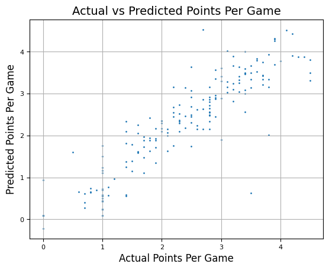

```python
import matplotlib.pyplot as plt
plt.scatter(pd.to_numeric(df6['points_per_game']), df6['model_prediction_ppg'], s = 1)
plt.rc('xtick', labelsize=10)
plt.tick_params(axis='both', which='major', labelsize=8)
plt.xlabel('Actual Points Per Game', fontsize=12)
plt.ylabel('Predicted Points Per Game', fontsize=12)
plt.title('Actual vs Predicted Points Per Game', fontsize=14)
plt.grid(True)
plt.show()
```

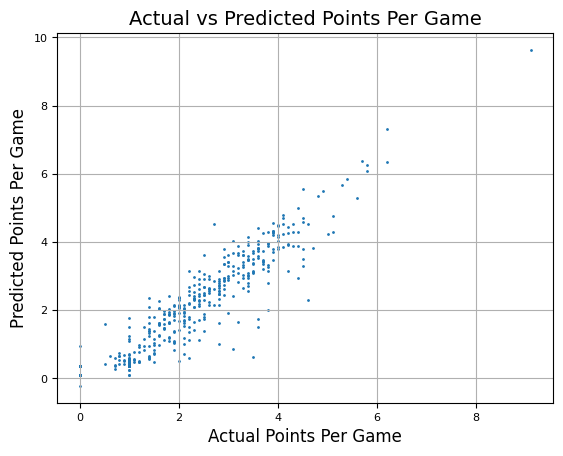

```python
df7 = pd.concat([df4, df6])

plt.scatter(pd.to_numeric(df7['points_per_game']), df7['model_prediction_ppg'], s = 1)
plt.rc('xtick', labelsize=10)
plt.tick_params(axis='both', which='major', labelsize=8)
plt.xlabel('Actual Points Per Game', fontsize=12)
plt.ylabel('Predicted Points Per Game', fontsize=12)
plt.title('Actual vs Predicted Points Per Game', fontsize=14)
plt.grid(True)
plt.show()
```

```python
from scipy.stats import pearsonr
#print(df7['points_per_game'].tolist())
pearsonr(df7['points_per_game'].tolist(), df7['model_prediction_ppg'].tolist())
```

```
PearsonRResult(statistic=np.float64(0.9512699945018145), pvalue=np.float64(0.0))
```

```python
df7['predicted_minus_real_ppg'] = df7['model_prediction_ppg']- pd.to_numeric(df7['points_per_game'])
#df2['model_prediction_ppg'] - pd.to_numeric(df2['points_per_game'])
df7.head()
```

|  | first_name | second_name | team_name | position_name | now_cost | points_per_game | removed | second_name | selected_by_percent | special | squad_number | status | team | team_code | total_points | transfers_in | transfers_in_event | transfers_out | transfers_out_event | value_form | value_season | web_name | region | team_join_date | birth_date | has_temporary_code | opta_code | minutes | goals_scored | … |
| --- | --- | --- | --- | --- | --- | --- | --- | --- | --- | --- | --- | --- | --- | --- | --- | --- | --- | --- | --- | --- | --- | --- | --- | --- | --- | --- | --- | --- | --- | --- |
| 15 | Bukayo | Saka | Arsenal | Midfielder | 100 | 5.1 | False | Saka | 15.3 | False | None | a | 1 | 3 | 127 | 0 | 0 | 0 | 0 | 0.0 | 12.7 | Saka | 241.0 | 2018-11-28 | 2001-09-05 | False | p223340 | 1724 | 6 | … |
| 16 | Martin | Ødegaard | Arsenal | Midfielder | 80 | 3.9 | False | Ødegaard | 3.3 | False | None | a | 1 | 3 | 116 | 0 | 0 | 0 | 0 | 0.0 | 14.5 | Ødegaard | 161.0 | 2021-08-20 | 1998-12-17 | False | p184029 | 2321 | 3 | … |
| 17 | Noni | Madueke | Arsenal | Midfielder | 70 | 3.8 | False | Madueke | 1.6 | False | None | a | 1 | 3 | 120 | 0 | 0 | 0 | 0 | 0.0 | 17.1 | Madueke | 241.0 | 2025-07-18 | 2002-03-10 | False | p248857 | 2028 | 7 | … |
| 18 | Gabriel | Martinelli Silva | Arsenal | Midfielder | 70 | 3.8 | False | Martinelli Silva | 1.4 | False | None | a | 1 | 3 | 125 | 0 | 0 | 0 | 0 | 0.0 | 17.9 | Martinelli | 30.0 | 2019-07-15 | 2001-06-18 | False | p444145 | 2284 | 8 | … |
| 19 | Leandro | Trossard | Arsenal | Midfielder | 70 | 4.0 | False | Trossard | 1.5 | False | None | a | 1 | 3 | 152 | 0 | 0 | 0 | 0 | 0.0 | 21.7 | Trossard | 21.0 | 2023-01-20 | 1994-12-04 | False | p116216 | 2546 | 8 | … |

```python
df8 = df7.sort_values(by='model_prediction_ppg', ascending = False)

#df9 = df8[df8['now_cost'] < 55]
#df7 = df6[pd.to_numeric(df6['points_per_game']) > 3]
#df9 = df9[df9['position_name'] == 'Midfielder']
#print(df9.head())

#df5[['second_name', 'now_cost', 'team_name', 'position_name', 'points_per_game','model_prediction_ppg', 'minutes', 'predicted_minus_real_ppg']]
df10 = df8[['second_name', 'team_name', 'position_name', 'now_cost', 'points_per_game','model_prediction_ppg', 'predicted_minus_real_ppg', 'minutes',
           'goals_scored', 'assists', 'expected_goals','expected_assists', 'threat', 'influence', 'creativity', 'expected_goals_conceded']]
```

```python
#df10.to_csv('final_data_withmodelpredictions_0708.csv', index=False)
```

### Team selection

Now we have some confidence about the predictions from our model, we can use predicted points per game to select players for our fantasy team. The strategy here is brute force: we get the program to sample a million different combinations of GKs, defenders, midfielders and forwards. The program records the price and the predicted points per game of the team, with and without subs.

```python
df11 = df10[pd.to_numeric(df10['model_prediction_ppg']) > 1.5]
sumdf = pd.DataFrame()
defenders = df11[df11['position_name'] == 'Defender']
goalkeepers = df11[df11['position_name'] == 'Goalkeeper']
midfielders = df11[df11['position_name'] == 'Midfielder']
forwards = df11[df11['position_name'] == 'Forward']
midfielders.sample(n=5)
forwards.sample(n = 3)
testdf = pd.concat([goalkeepers.sample(n = 1), defenders.sample(n = 5), midfielders.sample(n=5), forwards.sample(n=3)])
testdfminussubs = testdf.sort_values(by = 'model_prediction_ppg', ascending = False)[0:11]
print(testdfminussubs)
#print(100-36)
print(sum(testdf['now_cost']))
sum(testdf['model_prediction_ppg'])
print(testdf.iloc[:, 0].tolist())
srowdf = pd.DataFrame({'players': [testdf.iloc[:, 0].tolist()],
                        'total_cost': [sum(testdf['now_cost'])],
                        'total_predicted_ppg': [sum(testdf['model_prediction_ppg'])],
                        'predicted_ppg_minussubs': [sum(testdfminussubs['model_prediction_ppg'])]})
print(srowdf)
```

```
               second_name            second_name      team_name  \
438                 Mbeumo                 Mbeumo        Man Utd
533                   Wood                   Wood  Nott'm Forest
523            Gibbs-White            Gibbs-White  Nott'm Forest
215                Welbeck                Welbeck       Brighton
144                Collins                Collins      Brentford
1    Arrizabalaga Revuelta  Arrizabalaga Revuelta        Arsenal
223       Cucurella Saseta       Cucurella Saseta        Chelsea
516               Williams               Williams  Nott'm Forest
652                  Gomes                  Gomes         Wolves
354               Harrison               Harrison          Leeds
149                Pinnock                Pinnock      Brentford

    position_name  now_cost points_per_game  model_prediction_ppg  \
438    Midfielder        80             6.2              7.320744
```

[output cut: 43 more lines]

```python
df11 = df10[pd.to_numeric(df10['model_prediction_ppg']) > 1.5]
sumdf = pd.DataFrame()
defenders = df11[df11['position_name'] == 'Defender']
goalkeepers = df11[df11['position_name'] == 'Goalkeeper']
midfielders = df11[df11['position_name'] == 'Midfielder']
forwards = df11[df11['position_name'] == 'Forward']
```

```python
#for i in range(0, 500000):
 #   testdf = pd.concat([goalkeepers.sample(n = 1), defenders.sample(n = 5), midfielders.sample(n=5), forwards.sample(n=3)])
  #  testdfminussubs = testdf.sort_values(by = 'model_prediction_ppg', ascending = False)[0:11]
   # srowdf = pd.DataFrame({'players': [testdf.iloc[:, 0].tolist()],
    #                        'total_cost': [sum(testdf['now_cost'])],
    #                        'total_predicted_ppg': [sum(testdf['model_prediction_ppg'])],
    #                        'predicted_ppg_minussubs': [sum(testdfminussubs['model_prediction_ppg'])]})
   # sumdf = pd.concat([sumdf, srowdf])
   # print(i)
```

```python
#save or import as needed

#sumdf.to_csv('optimal_selections_sechalf.csv', index=False)
import pandas as pd
sumdf = pd.read_csv('optimal_selections.csv', index_col=0)
sumdf2 = pd.read_csv('optimal_selections_sechalf.csv', index_col=0)
sumdf = pd.concat([sumdf, sumdf2])
len(sumdf['predicted_ppg_minussubs'])
```

```
1079536
```

```python
print(sumdf[pd.to_numeric(sumdf['total_cost']) < 970].sort_values(by = 'predicted_ppg_minussubs', ascending = False).head(20))
resultsdf = sumdf[pd.to_numeric(sumdf['total_cost']) < 970].sort_values(by = 'predicted_ppg_minussubs', ascending = False)
resultsdf = resultsdf[pd.to_numeric(resultsdf['total_cost']) > 900]
#resultsdf.iloc[0,0]
```

```
                                                    total_cost  \
players
['Pickford', 'Gomes', 'van den Berg', "O'Reilly...         960
['Sels', 'Pinnock', 'Calafiori', 'Kadıoğlu', 'M...         960
['Santana de Moraes', 'Ignacio Bueno', 'Lamptey...         940
['Raya Martín', 'Dunk', 'Zinchenko', 'Mitchell'...         965
['Raya Martín', 'White', 'Todibo', 'Dalot Teixe...         965
['Pickford', 'Kadıoğlu', 'Zinchenko', 'White', ...         965
['Raya Martín', 'Danso', 'Schär', 'Tarkowski', ...         945
['Bentley', 'Mitchell', 'Todibo', 'Khusanov', '...         925
['Lynch Sánchez', 'van Dijk', 'van den Berg', '...         945
['Kelleher', 'Kayode', 'Muñoz Mejía', 'van den ...         955
['Raya Martín', 'Konaté', 'Timber', 'Scarles', ...         945
['Jörgensen', 'Milenković', 'Senesi Barón', 'Wa...         945
['Raya Martín', 'Calafiori', 'Botman', 'Gvardio...         965
['Sels', 'Ignacio Bueno', 'Agbadou', 'Moreno Lo...         950
['Santana de Moraes', 'Robinson', 'Castagne', '...         950
['Pickford', 'Maatsen', 'Moreno Lopera', 'Scarl...         920
['Dúbravka', 'Calafiori', 'Zinchenko', 'Drăguși...         930
['Onana', 'Aké', 'Maatsen', 'de Ligt', 'Krafth'...         960
['Santana de Moraes', 'van Dijk', 'Romero', 'Le...         960
['Lynch Sánchez', 'Todibo', 'dos Santos Magalhã...         930

                                                    total_predicted_ppg  \
players
['Pickford', 'Gomes', 'van den Berg', "O'Reilly...            62.473382
['Sels', 'Pinnock', 'Calafiori', 'Kadıoğlu', 'M...            63.712964
['Santana de Moraes', 'Ignacio Bueno', 'Lamptey...            63.486841
['Raya Martín', 'Dunk', 'Zinchenko', 'Mitchell'...            64.540900
['Raya Martín', 'White', 'Todibo', 'Dalot Teixe...            62.640689
['Pickford', 'Kadıoğlu', 'Zinchenko', 'White', ...            63.191921
['Raya Martín', 'Danso', 'Schär', 'Tarkowski', ...            61.527222
['Bentley', 'Mitchell', 'Todibo', 'Khusanov', '...            62.244038
['Lynch Sánchez', 'van Dijk', 'van den Berg', '...            62.436048
['Kelleher', 'Kayode', 'Muñoz Mejía', 'van den ...            62.111808
['Raya Martín', 'Konaté', 'Timber', 'Scarles', ...            63.594433
['Jörgensen', 'Milenković', 'Senesi Barón', 'Wa...            61.646085
['Raya Martín', 'Calafiori', 'Botman', 'Gvardio...            63.484533
['Sels', 'Ignacio Bueno', 'Agbadou', 'Moreno Lo...            61.884342
['Santana de Moraes', 'Robinson', 'Castagne', '...            61.119529
```

[output cut: 13 more lines]

```
['Pickford', 'Kadıoğlu', 'Zinchenko', 'White', ...                55.783313
['Raya Martín', 'Danso', 'Schär', 'Tarkowski', ...                55.643764
['Bentley', 'Mitchell', 'Todibo', 'Khusanov', '...                55.595845
['Lynch Sánchez', 'van Dijk', 'van den Berg', '...                55.578335
['Kelleher', 'Kayode', 'Muñoz Mejía', 'van den ...                55.416470
['Raya Martín', 'Konaté', 'Timber', 'Scarles', ...                55.282517
['Jörgensen', 'Milenković', 'Senesi Barón', 'Wa...                55.161436
['Raya Martín', 'Calafiori', 'Botman', 'Gvardio...                55.128349
['Sels', 'Ignacio Bueno', 'Agbadou', 'Moreno Lo...                54.999839
['Santana de Moraes', 'Robinson', 'Castagne', '...                54.976826
['Pickford', 'Maatsen', 'Moreno Lopera', 'Scarl...                54.966646
['Dúbravka', 'Calafiori', 'Zinchenko', 'Drăguși...                54.938366
['Onana', 'Aké', 'Maatsen', 'de Ligt', 'Krafth'...                54.885331
['Santana de Moraes', 'van Dijk', 'Romero', 'Le...                54.831940
['Lynch Sánchez', 'Todibo', 'dos Santos Magalhã...                54.827735
```

### Selection criteria

The code worked and we now have data on different combinations of players. The strategy now is to bring in real-life heuristics to make the final team selection of the best teams the program could produce.

**Selection criteria**

1. Cunha and Mbeumo not together
2. Few United and Arsenal players as they have poor fixtures
3. Chelsea, Aston Villa, West Ham players preferred as they have good fixtures
4. More CBs than FBs
5. No Gakpo, Isak, Delap, Trossard, Jao pedro (likely to lose minutes)

```python
#print(len(resultsdf['players']))
index = 13
#print(resultsdf['total_cost'])
resultsdf.iloc[index:,].head(30)
resultsdf.iloc[index]
```

```
total_cost                 950.000000
total_predicted_ppg         61.884342
predicted_ppg_minussubs     54.999839
Name: ['Sels', 'Ignacio Bueno', 'Agbadou', 'Moreno Lopera', 'Lacroix', "O'Reilly", 'Palmer', 'Salah', 'Damsgaard', 'Rice', 'Hughes', 'Bowen', 'Watkins', 'Wissa'], dtype: float64
```

```python
!jupyter nbconvert --execute --to html fpl.ipynb
```

```
[NbConvertApp] Converting notebook fpl.ipynb to html
[NbConvertApp] WARNING | Alternative text is missing on 2 image(s).
[NbConvertApp] Writing 481574 bytes to fpl.html
```